# PML Summary Stats and eSet Creation

M. Muzamil Khan

08/09/2021

```r
#library(hashmap)
library(ggplot2)
library(stringr)
library(DT)
library(plyr)
library(dplyr)
library(biomaRt)
library(Biobase)
library(reshape2)
library(formattable)
library(VennDiagram)
library(hypeR)
library(xlsx)
PATH <- getwd()
```

## Overview

The paired-end reads was aligned and mapped using Rsubread package with featureCounts as a quantifier. The reads were aligned to the hg38 human genome. The sequencing kit used was ‘Kapa Biosystems RNA HyperPrep Library Kit with RiboErase’; a stranded library using dUTPs to generate cDNA with the 2nd strand(reverse strand) hence the ‘reverse stranded’ option in featureCounts (`strandSpecific=2`) must be used.

Gene annotation is performed while doing the featureCount mapping using the human hg38 ensembl ids. The script used in performing the pre-processing is stored in scc in the location `$MLAB/projects/oralcancer/premalignant/evan_rsubread_test/ProcessRnaSeqFeatureCountsEnsemble.R` and the corresponding logfile is `/restricted/projectnb/montilab-p/projects/oralcancer/premalignant/evan_rsubread_test/monti_rnaseq_05-12.qlog`

**Few considerations: Cytobrush samples were removed due to their poor mapping quality and Inflammatory group was removed as they were not relevant to this study.**

[output not shown]

[output cut: 85 more lines]

```r
annotData
```

```
There were 33 warnings (use warnings() to see them)
```

## Patient Summary

```r
df <- data.frame(row.names = unique(annotData$Class))
class_groups <- data.frame(table(annotData$Class))
df$all <- class_groups$Freq

type_groups <- data.frame(table(annotData$Class[which(annotData$Type=='Cytobrush')]))
df$type_cytobrush <- c(type_groups$Freq[1],0,0,type_groups$Freq[2], type_groups$Freq[3])

df$unique <- df$all - df$type

datatable(df)
```

|  | all | type_cytobrush | unique |
| --- | --- | --- | --- |
| Dysplasia | 12 | 3 | 9 |
| HkNR | 25 | 0 | 25 |
| Inflammatory | 29 | 0 | 29 |
| Control | 17 | 7 | 10 |
| Cancer | 12 | 7 | 5 |

```r
type <- data.frame(table(annotData$Type))
names(type) <- c("Type", "Freq")

datatable(type)
```

|  | Type | Freq |
| --- | --- | --- |
| 1 | Biopsy | 78 |
| 2 | Cytobrush | 17 |

## Reads Summary

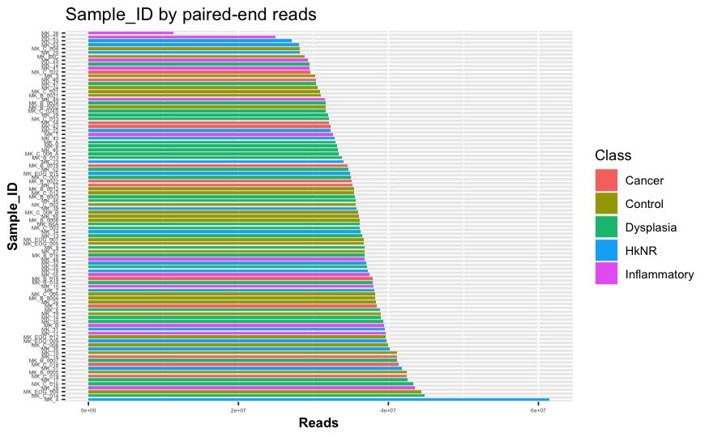

```r
ggplot(data = fc_trans, aes(x = reorder(Sample_ID, -Total_fragments), y = Total_fragments, fill = Class)) +
  geom_bar(stat = "identity", width = 0.75,) +
  labs(title = "Sample_ID by paired-end reads", y = "Reads", x = "Sample_ID")+ coord_flip() +
  theme(axis.text = element_text(size = 4), axis.title = element_text(size = 10, face = "bold"))
```

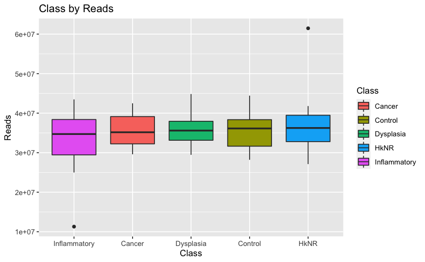

```r
ggplot(fc_trans,aes(reorder(Class, Total_fragments, median, order = TRUE), Total_fragments, fill = Class)) +
  geom_boxplot(aes(fill=Class)) +
  labs(title="Class by Reads",y="Reads",x="Class")
```

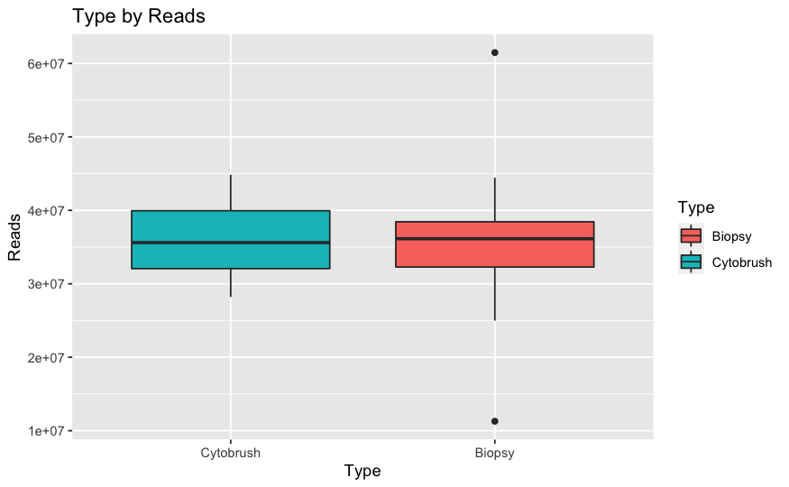

```r
ggplot(fc_trans,aes(reorder(Type, Total_fragments, median, order = TRUE), Total_fragments, fill = Type)) +
  geom_boxplot(aes(fill=Type)) +
  labs(title="Type by Reads",y="Reads",x="Type")
```

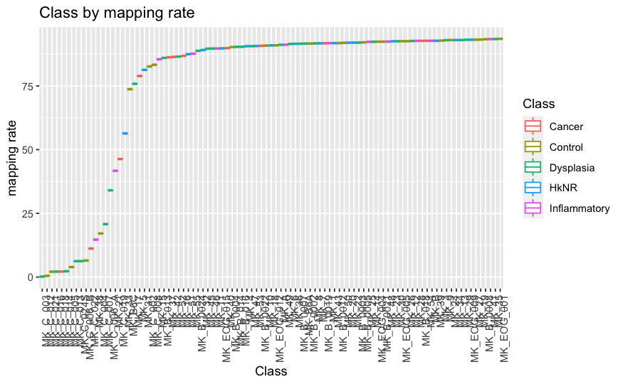

```r
ggplot(fc_trans,aes(reorder(Sample_ID, mapping_rate, median, order = TRUE), mapping_rate, color = Class)) +
  geom_boxplot(width=1)+
  labs(title="Class by mapping rate",y="mapping rate",x="Class")+
 theme(axis.text.x = element_text(angle = 90, hjust = 1))
```

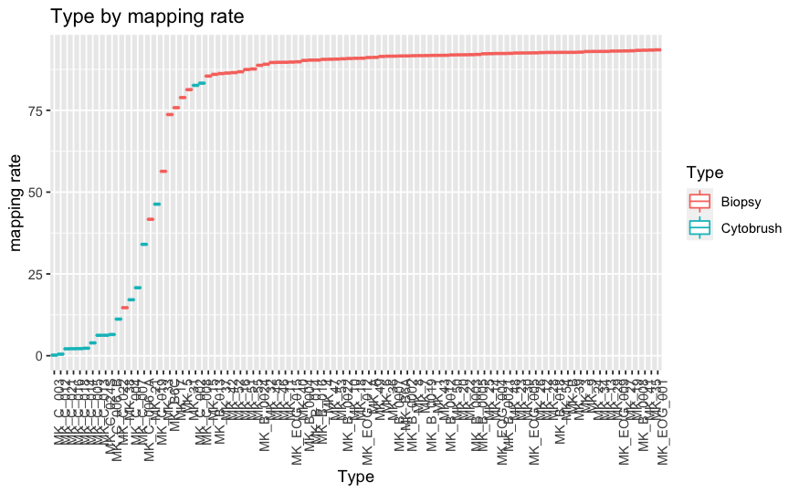

```r
ggplot(fc_trans,aes(reorder(Sample_ID, mapping_rate, median, order = TRUE), mapping_rate, color = Type)) +
  geom_boxplot(width=1)+
  labs(title="Type by mapping rate",y="mapping rate",x="Type")+
 theme(axis.text.x = element_text(angle = 90, hjust = 1))
```

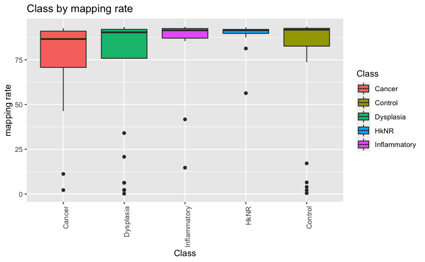

```r
ggplot(fc_trans,aes(reorder(Class, mapping_rate, median, order = TRUE), mapping_rate, fill = Class)) +
  geom_boxplot(aes(fill=Class))+
  labs(title="Class by mapping rate",y="mapping rate",x="Class")+
 theme(axis.text.x = element_text(angle = 90, hjust = 1))
```

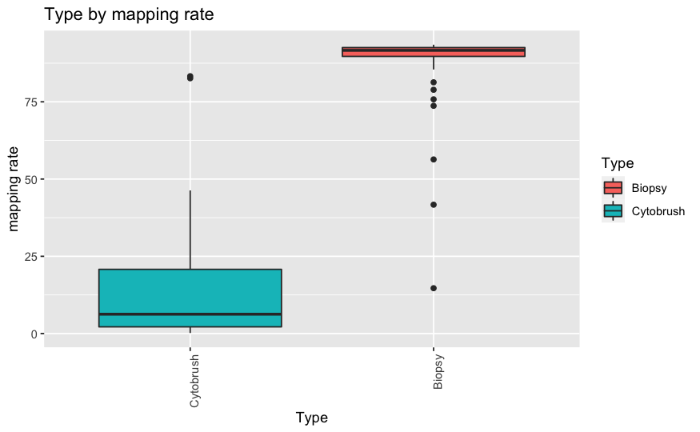

```r
ggplot(fc_trans,aes(reorder(Type, mapping_rate, median, order = TRUE), mapping_rate, fill = Type)) +
  geom_boxplot(aes(fill=Type))+
  labs(title="Type by mapping rate",y="mapping rate",x="Type")+
 theme(axis.text.x = element_text(angle = 90, hjust = 1))
```

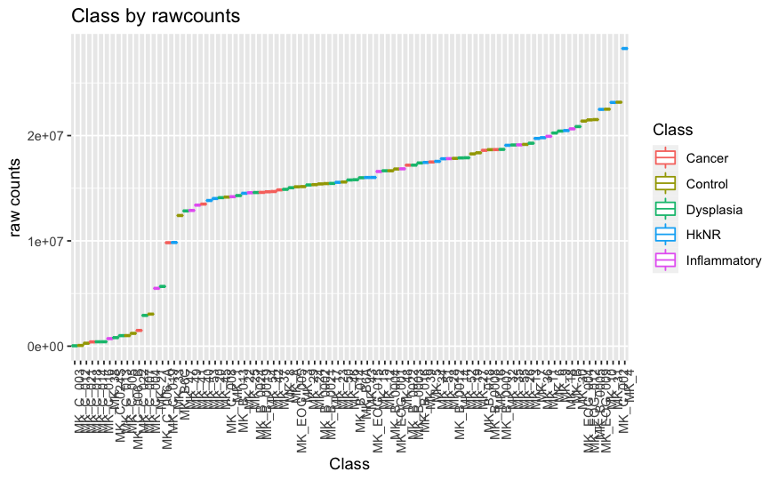

```r
ggplot(fc_trans,aes(reorder(Sample_ID, rawcounts, median, order = TRUE), rawcounts, color = Class)) +
  geom_boxplot(width=1)+
  labs(title="Class by rawcounts",y="raw counts",x="Class")+
 theme(axis.text.x = element_text(angle = 90, hjust = 1))
```

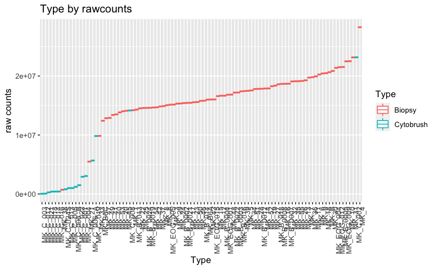

```r
ggplot(fc_trans,aes(reorder(Sample_ID, rawcounts, median, order = TRUE), rawcounts, color = Type)) +
  geom_boxplot(width=1)+
  labs(title="Type by rawcounts",y="raw counts",x="Type")+
 theme(axis.text.x = element_text(angle = 90, hjust = 1))
```

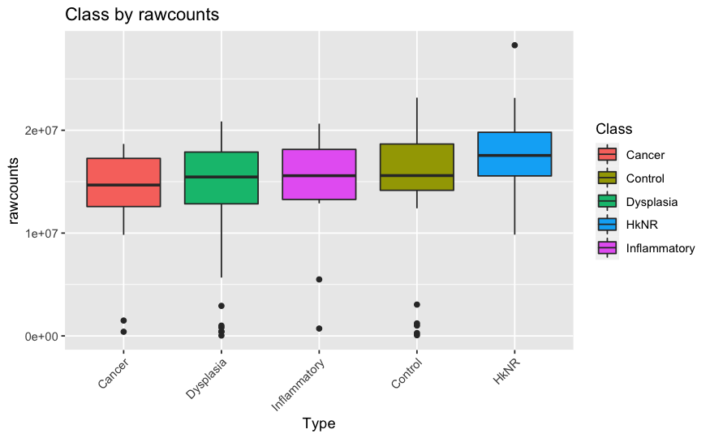

```r
ggplot(fc_trans,aes(reorder(Class, rawcounts, median, order = TRUE), rawcounts, fill = Class)) +
  geom_boxplot(aes(fill=Class))+
  labs(title="Class by rawcounts",y="rawcounts",x="Type")+
 theme(axis.text.x = element_text(angle = 45, hjust = 1))
```

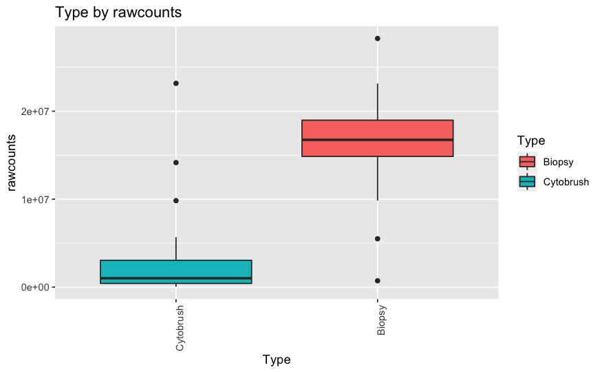

```r
ggplot(fc_trans,aes(reorder(Type, rawcounts, median, order = TRUE), rawcounts, fill = Type)) +
  geom_boxplot(aes(fill=Type))+
  labs(title="Type by rawcounts",y="rawcounts",x="Type")+
 theme(axis.text.x = element_text(angle = 90, hjust = 1))
```

## ExpressionSet creation

```r
eSet <- Biobase::ExpressionSet(assayData = as.matrix(assaydata),
                              phenoData = AnnotatedDataFrame(fc_trans[match(colnames(assaydata),rownames(fc_trans)),]))

saveRDS(eSet, file.path(PATH, "pml/eSet_2021_08_12.RDS"))
```